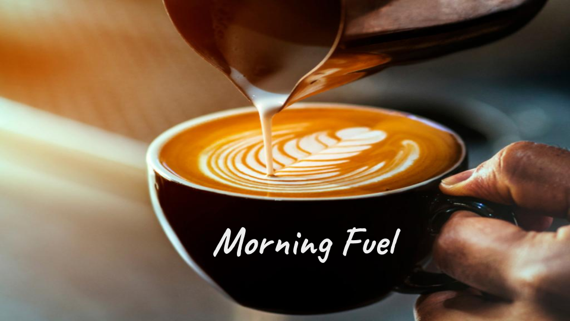

```python
from IPython.display import Image
from IPython.display import display, Image
display(Image(filename='Morning Fuel.png'))
```

# Recommendation

we recommend Morning Fuel courses on this neighborhoods, they meet the neccesary criterias;

- Central Park,
- Five Points,
- Gateway-Green Valley Ranch,
- Highland,
- University

# CONLUSIONS

AURARIA AND CBD ARE THE NEIGHBORHOODS WITH THE HIGHEST PEOPLE AGE OF 18-35, BUT THEY DO NOT HAVE AFFLUENT HOUSEHOLDS. LEAVING THOSE TWO OUT (which can still be used later on in contemplating other neighborhoods to open new stores), UNIVERSITY HAS THE HIGHEST PEOPLE AGE OF 18-35 YEARS. WE GET THE TOP 3 NEIGHBORHOODS BY APPLYING THE PERCENTAGE OF AFFLUENT HOUSEHOLDS TO THE AMOUNT OF 18-35 YEAR OLD PEOPLE (PEOPLE WHO WILL ACTUALLY BUY).

# Introduction

Polarity Ventures is assisting a customer, Morning Fuel, who runs coffee shops throughout Colorado. The coffee shops of the company sell high-quality, responsibly sourced coffee, pastries, and sandwiches. They have three Fort Collins locations and plan to expand into Denver.

Our customer believes that a new store should be located near rich households, and the store caters to the 20-35 year old population.

To help with the search, the Analytic team gathered geographical and demographic information on Denver's neighborhoods. We also gathered information from Starbucks locations in Denver. Starbucks and Morning Fuel do not competing for the same customers; the team used their location as an example.

**For the purpose of this analysis**, the end results will be providing Morning Fuel with the best neighborhood locations in denver where the new shops should be located. By providing Morning Fuel with the following information;

- A visualization of Denver's neighborhoods and the Starbucks store locations.
- Find the neighborhoods with the highest proportion of people in the target demographic.
- Select the top three neighborhoods where your client should focus their search.

## Data

Starbucks locations were scrapped from the Starbucks store locator webpage by Chris Meller. Statistical Neighborhood information from the City of Denver Open Data Catalog, CC BY 3.0 license. Census information from the United States Census Bureau. Publicly available information.

## Data Description

You have assembled information from three different sources ([locations](https://github.com/chrismeller/), [neighborhoods](http://data.denvergov.org), [demographics](https://www.census.gov/)):

#### Starbucks locations in Denver, Colorado

- "StoreNumber" - Store Number as assigned by Starbucks
- "Name" - Name identifier for the store
- "PhoneNumber" - Phone number for the store
- "Street 1, 2, and 3" - Address for the store
- "PostalCode" - Zip code of the store
- "Longitude, Latitude" - Coordinates of the store

#### Neighborhoods' geographical information

- "NBHD_ID" - Neighborhood ID (matches the census information)
- "NBHD_NAME" - Name of the statistical neighborhood
- "Geometry" - Polygon that defines the neighborhood

#### Demographic information

- "NBHD_ID" - Neighborhood ID (matches the geographical information)
- "NBHD_NAME' - Nieghborhood name
- "POPULATION_2010' - Population in 2010
- "AGE_ " - Number of people in each age bracket (< 18, 18-34, 35-65, and > 65)
- "NUM_HOUSEHOLDS" - Number of households in the neighborhood
- "FAMILIES" - Number of families in the neighborhood
- "NUM_HHLD_100K+" - Number of households with income above 100 thousand USD per year

```python
%%capture
pip install geopandas
```

```python
# Importing pandas
import pandas as pd
import geopandas as gpd
import matplotlib.pyplot as plt
import seaborn as sns
import numpy as np

# Reading in the data
census = pd.read_csv('census.csv')
denver = pd.read_csv('denver.csv')
neighborhoods = gpd.read_file("C:/Users/hp/Desktop/Projects/Coffee Shop/neighborhoods.shp")
neighborhoods
```

|  | NBHD_ID | NBHD_NAME | geometry |
| --- | --- | --- | --- |
| 0 | 2 | Auraria | POLYGON ((-105.00042 39.74552, -105.00041 39.7... |
| 1 | 21 | Cory - Merrill | POLYGON ((-104.94070 39.69540, -104.94070 39.6... |
| 2 | 7 | Belcaro | POLYGON ((-104.94070 39.71156, -104.94069 39.7... |
| 3 | 70 | Washington Park | POLYGON ((-104.95931 39.71566, -104.95931 39.7... |
| 4 | 71 | Washington Park West | POLYGON ((-104.97342 39.68982, -104.97356 39.6... |
| ... | ... | ... | ... |
| 73 | 77 | Whittier | POLYGON ((-104.95977 39.75072, -104.96038 39.7... |
| 74 | 18 | Cole | POLYGON ((-104.95975 39.76199, -104.96037 39.7... |
| 75 | 76 | Westwood | POLYGON ((-105.03970 39.71125, -105.03849 39.7... |
| 76 | 62 | Sunnyside | POLYGON ((-104.99818 39.78256, -104.99820 39.7... |
| 77 | 23 | DIA | POLYGON ((-104.76269 39.79833, -104.76290 39.7... |

78 rows × 3 columns

### A visualization of Denver's Neighborhoods and the Starbucks store locations.

Since we'll be using Starbucks data as a landmark, let's have a look at where each Starbucks location is. By knowing this and other information when we dig further into the data, we'll be able to determine crucial spots where additional stores should be opened.

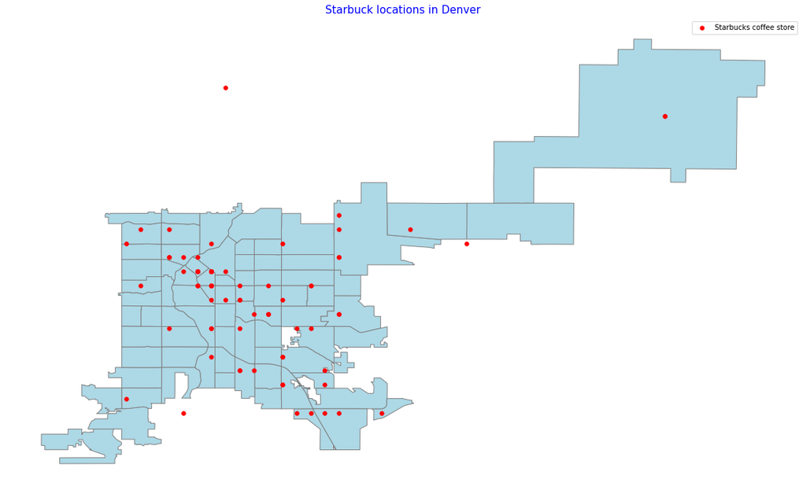

```python
#convert denver data to geographical data
denver_geo = gpd.GeoDataFrame(denver, geometry=gpd.points_from_xy(denver.Longitude, denver.Latitude))


fig, ax = plt.subplots(figsize=(20,20))
ax.set_aspect('equal')
ax=neighborhoods.plot(ax=ax,color='lightblue', edgecolor='grey', legend =True)
ax.set_axis_off()
denver_geo.plot(ax=ax, markersize = 30, color = 'red', marker = 'o', label='Starbucks coffee store')
plt.title('Starbuck locations in Denver', color='blue',size=15)
plt.legend()
plt.show();
```

A map of Denver neighborhoods showing where starbucks are located.

### Find the neighborhood with the highest proportion of people in the target demographic

## To get the proportion of target customer we will be creating columns to hold this information.

We create some columns analyzing the desired variables.  
**ageprop_18_34** is the target age percentage  
**prop_highincome** is a percentage of the amount of affluent hh  
**ind** is index where we apply the high income households % to the amount of 18-35 age people. With this we can approach the amount of real target people in the neighborhood.

NOTE: Like the desired age rate (20-35) is not in the census as that, we will focus in 18-34 age rate that contains the desired one as it is prety similar.

```python
# proportion of people betwenn 18 - 34:
census['ageprop_18_34'] = census['AGE_18_TO_34'] / census['POPULATION_2010']
#for the missing figures in the family column fill wih the mean
over_100k_mean = census[census['NUM_HHLD_100K+'].notna()]['NUM_HHLD_100K+'].sum() / census[census['NUM_HHLD_100K+'].notna()]['NUM_HOUSEHOLDS'].sum()
# proportion of housholds with high income:
census['prop_highincome'] = census['NUM_HHLD_100K+'] / census['NUM_HOUSEHOLDS']
#  real target customers in the neighborhood.
census['ind']=census['prop_highincome']*census['AGE_18_TO_34']
```

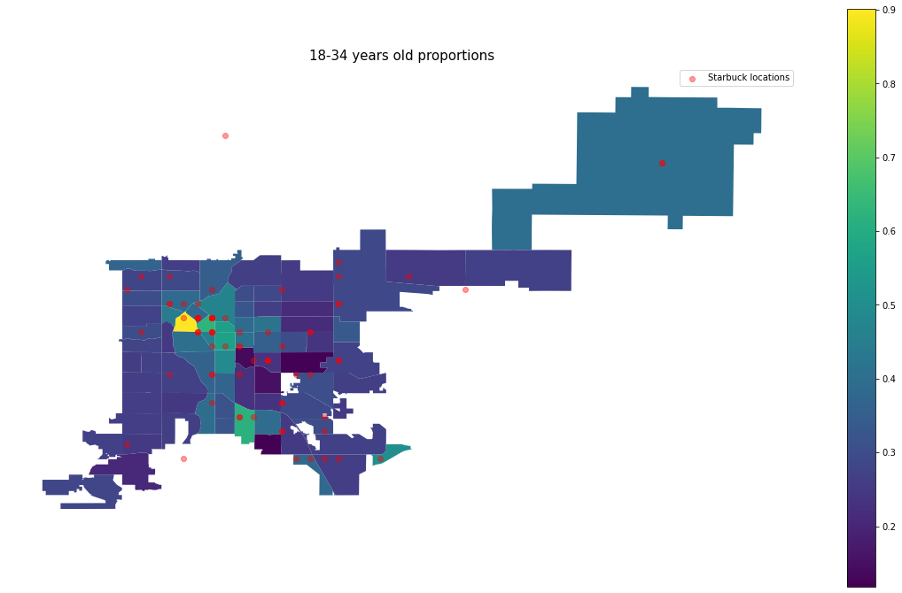

```python
# Calculate average proportion of people of age 18-34:
avg_prop_age_18_34 = census['ageprop_18_34'].mean()
#avg_prop_age_18_34

neighborhood_census = neighborhoods.merge(census, on='NBHD_ID', how='left').fillna(0)
neighborhoods

# Renaming columns
neighborhood_census.rename(columns={"NBHD_NAME_x":"NBHD_NAME","ind_y": "ind","POPULATION_2010_x":"POPULATION_2010","AGE_18_TO_34_x":"AGE_18_TO_34"}, inplace=True)

#Deleting duplicate column
for col in neighborhood_census.columns:
    if 'NBHD_NAME_y' in col:
        del neighborhood_census[col]
fig, ax1 = plt.subplots(figsize=(20,12))

# A heat map showing Age Demographic
neighborhood_census.plot(column='ageprop_18_34',legend=True,ax=ax1, label ='Proportion of people age 18 to 34')
ax1.set_axis_off()
denver_geo.plot(ax=ax1, color='red',legend=True,alpha=0.4, label='Starbuck locations')
ax1.legend()
ax1.set_title('18-34 years old proportions',size=15);
```

From the above map, using the scale to the proportion of people from age 18 to 34 with the highest proportion in yellow and less in purple.

# Target Neighborhoods

Now let's begin to narrow down our analysis, to get the neighborhoods that Morning Fuel will targeting in Denver.

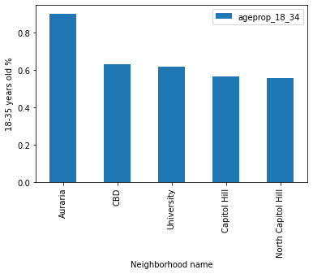

```python
# Target Neigborhoods
target_age_per=neighborhood_census.sort_values('ageprop_18_34', ascending=False).head()
target_age_per.plot(x='NBHD_NAME', y='ageprop_18_34', kind='bar', ylabel='18-35 years old %', xlabel='Neighborhood name');
```

Neighborhoods with highest proportion of 18 to 34 are;

- Auraria
- CBD
- University
- Capitol Hill
- North Capitol Hill

Now to see if this neighborhoods meet our other criterias

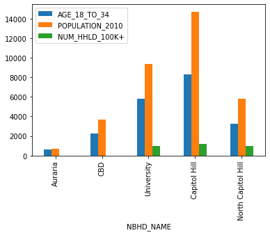

```python
# Plotting all critrias each neighborhood has to meet to be a target market
target_age_per.head().plot(x='NBHD_NAME',y=['AGE_18_TO_34','POPULATION_2010','NUM_HHLD_100K+'], kind='bar');
```

From this plots, we can see that the 2 neighbourhoods have the target age demographic **Auraria** and **CBD**, but they lack the second critria needeed, **Household making above 100k+**

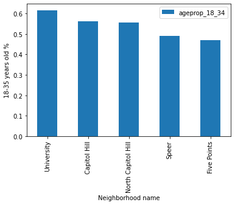

```python
# Removing all neighborhoods that dont meet the target market
census_aff=neighborhood_census[neighborhood_census['NUM_HHLD_100K+']>0]
census_aff.sort_values('ageprop_18_34', ascending=False)

# A visual Neighborhoods meeting the critria
census_aff.sort_values('ageprop_18_34',ascending=False).head().plot(x='NBHD_NAME',y='ageprop_18_34',kind='bar', ylabel='18-35 years old %', xlabel='Neighborhood name');
```

After removing Auraria and CBD, we can see that top 5 neighborhoods with most 18-35 % and that have affluent households.  
*1) University*  
2) Capitol Hill  
*3) North Capitol Hill*  
4) Speer  
*5) Five Points

Using Statistic analysis, getting the statistic distribution of our census data we can get a better understanding of the neigborhood

```python
census_aff.describe()
```

|  | NBHD_ID | POPULATION_2010 | AGE_LESS_18 | AGE_18_TO_34 | AGE_35_TO_65 | AGE_65_PLUS | NUM_HOUSEHOLDS | FAMILIES | NUM_HHLD_100K+ | ageprop_18_34 | prop_highincome | ind |
| --- | --- | --- | --- | --- | --- | --- | --- | --- | --- | --- | --- | --- |
| count | 48.000000 | 48.000000 | 48.000000 | 48.000000 | 48.000000 | 48.000000 | 48.000000 | 48.000000 | 48.000000 | 48.000000 | 48.000000 | 48.000000 |
| mean | 42.604167 | 10273.854167 | 2260.937500 | 3133.312500 | 3814.270833 | 1065.333333 | 4456.187500 | 2147.625000 | 1095.208333 | 0.307053 | 0.252974 | 733.455944 |
| std | 22.169309 | 5006.996492 | 2022.145116 | 1674.986518 | 1708.502290 | 634.308749 | 2030.361562 | 1202.393281 | 650.866197 | 0.096773 | 0.150507 | 489.277768 |
| min | 1.000000 | 5327.000000 | 194.000000 | 994.000000 | 1867.000000 | 360.000000 | 1695.000000 | 461.000000 | 120.000000 | 0.121368 | 0.063297 | 108.238469 |
| 25% | 26.750000 | 7427.750000 | 1271.750000 | 2007.750000 | 2881.250000 | 706.250000 | 3321.500000 | 1395.000000 | 439.250000 | 0.260390 | 0.117772 | 348.942499 |
| 50% | 42.500000 | 8823.500000 | 2015.500000 | 2692.000000 | 3453.000000 | 931.500000 | 3840.000000 | 1896.500000 | 1043.500000 | 0.272033 | 0.231022 | 654.481507 |
| 75% | 62.500000 | 11756.750000 | 2606.000000 | 3642.750000 | 4329.250000 | 1229.250000 | 5240.250000 | 2446.000000 | 1680.000000 | 0.312650 | 0.340967 | 927.561699 |
| max | 78.000000 | 30348.000000 | 11137.000000 | 8274.000000 | 10405.000000 | 3383.000000 | 10856.000000 | 7056.000000 | 2748.000000 | 0.616960 | 0.671554 | 2691.589443 |

## Applying the statistical analysis results into the data to pin point the target markets

We would like a neighborhood with a good population and affluent households aside a good percentage of target age (20-35). We can see 75% of pop (11756), 18-34 age (3642.75) and NUM_HHLD_100K+ (1680)

```python
denver_best = neighborhood_census[(neighborhood_census['POPULATION_2010']>11756.75) | (neighborhood_census['AGE_18_TO_34']>3642.75) | (neighborhood_census['NUM_HHLD_100K+']>1680)].reset_index()
denver_best.drop(columns='index', inplace=True)
final=denver_best[['NBHD_NAME','geometry','POPULATION_2010','AGE_18_TO_34','ageprop_18_34','prop_highincome','ind']].sort_values(['ageprop_18_34'], ascending=False)
final.head()
```

|  | NBHD_NAME | geometry | POPULATION_2010 | AGE_18_TO_34 | ageprop_18_34 | prop_highincome | ind |
| --- | --- | --- | --- | --- | --- | --- | --- |
| 5 | University | POLYGON ((-104.95945 39.68473, -104.95945 39.6... | 9375.0 | 5784.0 | 0.616960 | 0.263634 | 1524.858739 |
| 11 | Capitol Hill | POLYGON ((-104.97341 39.74003, -104.97299 39.7... | 14708.0 | 8274.0 | 0.562551 | 0.112657 | 932.120671 |
| 1 | Speer | POLYGON ((-104.97325 39.71840, -104.97323 39.7... | 10954.0 | 5361.0 | 0.489410 | 0.230285 | 1234.556681 |
| 15 | Five Points | POLYGON ((-104.97192 39.77030, -104.97335 39.7... | 12712.0 | 5961.0 | 0.468927 | 0.262254 | 1563.296909 |
| 4 | Highland | POLYGON ((-104.99820 39.76930, -104.99821 39.7... | 8429.0 | 3269.0 | 0.387828 | 0.412491 | 1348.432825 |

```python
# Sorting the data to show the top neighborhoods by age proportion of target demo and affluent household proportion
denver_best.sort_values(['ageprop_18_34','prop_highincome'], ascending=([False,False])).head(5)
```

|  | NBHD_ID | NBHD_NAME | geometry | POPULATION_2010 | AGE_LESS_18 | AGE_18_TO_34 | AGE_35_TO_65 | AGE_65_PLUS | NUM_HOUSEHOLDS | FAMILIES | NUM_HHLD_100K+ | ageprop_18_34 | prop_highincome | ind |
| --- | --- | --- | --- | --- | --- | --- | --- | --- | --- | --- | --- | --- | --- | --- |
| 5 | 64 | University | POLYGON ((-104.95945 39.68473, -104.95945 39.6... | 9375.0 | 826.0 | 5784.0 | 2246.0 | 519.0 | 3759.0 | 1218.0 | 991.0 | 0.616960 | 0.263634 | 1524.858739 |
| 11 | 9 | Capitol Hill | POLYGON ((-104.97341 39.74003, -104.97299 39.7... | 14708.0 | 408.0 | 8274.0 | 5155.0 | 871.0 | 10856.0 | 1201.0 | 1223.0 | 0.562551 | 0.112657 | 932.120671 |
| 1 | 59 | Speer | POLYGON ((-104.97325 39.71840, -104.97323 39.7... | 10954.0 | 707.0 | 5361.0 | 3970.0 | 916.0 | 7304.0 | 1400.0 | 1682.0 | 0.489410 | 0.230285 | 1234.556681 |
| 15 | 26 | Five Points | POLYGON ((-104.97192 39.77030, -104.97335 39.7... | 12712.0 | 1446.0 | 5961.0 | 4660.0 | 645.0 | 6406.0 | 1711.0 | 1680.0 | 0.468927 | 0.262254 | 1563.296909 |
| 4 | 36 | Highland | POLYGON ((-104.99820 39.76930, -104.99821 39.7... | 8429.0 | 1296.0 | 3269.0 | 3070.0 | 794.0 | 4131.0 | 1495.0 | 1704.0 | 0.387828 | 0.412491 | 1348.432825 |

```python
# Sorting the data to show the top neighborhoods by the real target people in the neighborhood.
denver_best.sort_values('ind', ascending=False).head(5)
```

|  | NBHD_ID | NBHD_NAME | geometry | POPULATION_2010 | AGE_LESS_18 | AGE_18_TO_34 | AGE_35_TO_65 | AGE_65_PLUS | NUM_HOUSEHOLDS | FAMILIES | NUM_HHLD_100K+ | ageprop_18_34 | prop_highincome | ind |
| --- | --- | --- | --- | --- | --- | --- | --- | --- | --- | --- | --- | --- | --- | --- |
| 12 | 60 | Central Park | POLYGON ((-104.86604 39.79841, -104.86604 39.7... | 13948.0 | 3516.0 | 4008.0 | 6045.0 | 379.0 | 4092.0 | 2759.0 | 2748.0 | 0.287353 | 0.671554 | 2691.589443 |
| 14 | 28 | Gateway - Green Valley Ranch | POLYGON ((-104.80990 39.77283, -104.80988 39.7... | 29201.0 | 10074.0 | 7778.0 | 10405.0 | 944.0 | 9427.0 | 7056.0 | 2192.0 | 0.266361 | 0.232524 | 1808.568580 |
| 15 | 26 | Five Points | POLYGON ((-104.97192 39.77030, -104.97335 39.7... | 12712.0 | 1446.0 | 5961.0 | 4660.0 | 645.0 | 6406.0 | 1711.0 | 1680.0 | 0.468927 | 0.262254 | 1563.296909 |
| 5 | 64 | University | POLYGON ((-104.95945 39.68473, -104.95945 39.6... | 9375.0 | 826.0 | 5784.0 | 2246.0 | 519.0 | 3759.0 | 1218.0 | 991.0 | 0.616960 | 0.263634 | 1524.858739 |
| 4 | 36 | Highland | POLYGON ((-104.99820 39.76930, -104.99821 39.7... | 8429.0 | 1296.0 | 3269.0 | 3070.0 | 794.0 | 4131.0 | 1495.0 | 1704.0 | 0.387828 | 0.412491 | 1348.432825 |

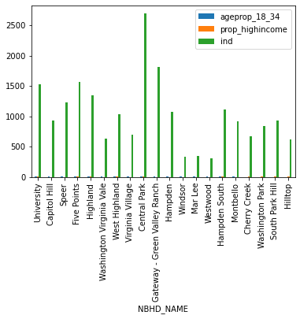

```python
# The top neighborhoods by the real target people in the neighborhood.
final.plot(x='NBHD_NAME', y=['ageprop_18_34','prop_highincome','ind'], kind='bar');
```

After applyting the 75% filter, we get the five best neighborhoods (regarding target age %) for a new coffee shop are:  
*1) University*  
2) Capitol Hill  
*3) Speer Hill*  
4) Five Points  
*5) Highland

North Capitol stayed behind after last "75%" filter

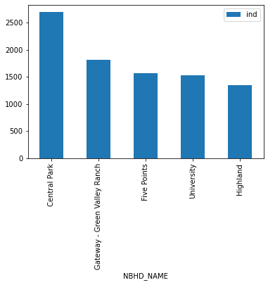

```python
top_three=final.sort_values('ind', ascending=False).head()
top_three.plot(x='NBHD_NAME', y='ind', kind='bar');
```

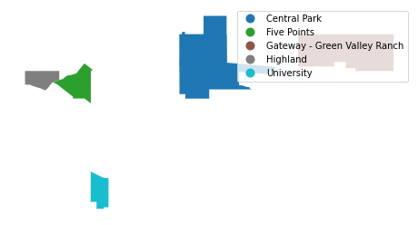

```python
fig, ax = plt.subplots(figsize=(8,8))
ax=top_three.plot(ax=ax, column='NBHD_NAME', legend=True)
ax.set_axis_off()
```